# Assignment 2

“Your task is to train a classifier in R that based on EEG sensor data is capable of predicting whether a patient has eyelids open or closed.”

```r
if (rstudioapi::isAvailable()) {
  setwd(dirname(rstudioapi::getActiveDocumentContext()$path))
}

# Load libraries ---------------------------------------------------------------
# Create our function "using()"
using <- \(pkg) {
  # if a package is not installed, install it
  if (!rlang::is_installed(pkg)) {
    install.packages(pkg, repo = "https://cloud.r-project.org")
  }
  # load the package
  library(pkg, character.only = TRUE)
}

using("data.table")
using("plotly")
using("caret")
using("rpart")
using("rpart.plot")
using("ranger")
using("adabag")
using("xgboost")
using("imbalance") # Oversampling
using("ROSE") # Synthetic generation of new data to rebalance
using("e1071") # for building SVM model
using("class") #knn implementation
using("mltools") # for xgboost
```

# EEG Data

## 1. Data importing

**Description:** Import the EEG data from the attachments in this assignment. The dataset contains - 16 EEG numerical features - 1 label (0-open | 1-closed) (Train and test are already split (eeg_training.csv, eeg_test.csv))

```r
training <- fread("./data/eeg_eyelid_training.csv")
testing <- fread("./data/eeg_eyelid_test.csv")

nrow(training) / (nrow(testing) + nrow(training))
```

```
## [1] 0.6863534
```

Note: Split is about ~70-30

## 2. Shortly explore the dataset (EDA), perform data cleansing and preprocessing.

```r
str(training)
```

```
## Classes 'data.table' and 'data.frame':   8193 obs. of  17 variables:
##  $ EEG1 : num  4292 4274 4288 4286 4313 ...
##  $ EEG2 : num  4263 4256 4268 4264 4249 ...
##  $ EEG3 : num  4069 4075 4090 4062 4063 ...
##  $ EEG4 : num  3989 4003 4016 4001 4007 ...
##  $ EEG5 : num  4617 4617 4632 4623 4596 ...
##  $ EEG6 : num  4272 4229 4330 4194 4245 ...
##  $ EEG7 : num  4343 4331 4336 4332 4321 ...
##  $ EEG8 : num  4229 4218 4226 4236 4217 ...
##  $ EEG9 : num  4111 4116 4135 4117 4111 ...
##  $ EEG10: num  4217 4185 4201 4205 4185 ...
##  $ EEG11: num  4624 4601 4623 4622 4594 ...
##  $ EEG12: num  4191 4188 4199 4203 4191 ...
##  $ EEG13: num  4238 4232 4225 6215 4241 ...
##  $ EEG14: num  4274 4269 4276 4281 4268 ...
##  $ EEG15: num  4596 4591 4592 4619 4602 ...
##  $ EEG16: num  4348 4342 4348 4363 4375 ...
##  $ Class: chr  "1-closed" "0-open" "1-closed" "0-open" ...
##  - attr(*, ".internal.selfref")=<externalptr>
```

```r
summary(training)
```

```
##       EEG1           EEG2           EEG3             EEG4           EEG5
##  Min.   :4198   Min.   :1040   Min.   :  4027   Min.   :2831   Min.   :  4566
##  1st Qu.:4280   1st Qu.:4250   1st Qu.:  4059   1st Qu.:3992   1st Qu.:  4613
##  Median :4293   Median :4262   Median :  4071   Median :4006   Median :  4618
##  Mean   :4301   Mean   :4263   Mean   :  4142   Mean   :4011   Mean   :  4665
##  3rd Qu.:4309   3rd Qu.:4270   3rd Qu.:  4083   3rd Qu.:4025   3rd Qu.:  4627
##  Max.   :7398   Max.   :4386   Max.   :567179   Max.   :4157   Max.   :362564
##                                NA's   :9
##       EEG6           EEG7           EEG8           EEG9            EEG10
##  Min.   :4054   Min.   :4305   Min.   :1816   Min.   :  3734   Min.   :1358
##  1st Qu.:4191   1st Qu.:4332   1st Qu.:4220   1st Qu.:  4109   1st Qu.:4191
##  Median :4242   Median :4339   Median :4229   Median :  4120   Median :4199
##  Mean   :4239   Mean   :4342   Mean   :4230   Mean   :  4201   Mean   :4201
##  3rd Qu.:4297   3rd Qu.:4347   3rd Qu.:4238   3rd Qu.:  4133   3rd Qu.:4209
##  Max.   :4382   Max.   :6474   Max.   :6215   Max.   :642564   Max.   :7144
##  NA's   :7837                                 NA's   :5
##      EEG11          EEG12          EEG13          EEG14          EEG15
##  Min.   :4571   Min.   :3273   Min.   :1816   Min.   :3091   Min.   : 276.4
##  1st Qu.:4605   1st Qu.:4190   1st Qu.:4221   1st Qu.:4267   1st Qu.:4590.3
##  Median :4613   Median :4200   Median :4229   Median :4276   Median :4602.6
##  Mean   :4616   Mean   :4201   Mean   :4231   Mean   :4278   Mean   :4603.7
##  3rd Qu.:4624   3rd Qu.:4211   3rd Qu.:4239   3rd Qu.:4286   3rd Qu.:4615.4
##  Max.   :5362   Max.   :6138   Max.   :6215   Max.   :6905   Max.   :4833.9
##
##      EEG16           Class
##  Min.   :  4206   Length:8193
##  1st Qu.:  4340   Class :character
##  Median :  4354   Mode  :character
##  Mean   :  4460
##  3rd Qu.:  4370
##  Max.   :715897
##
```

```r
#setnames(training, "Class", "eyes_state")
#setnames(testing, "Class", "eyes_state")
#training[, eyes_state := ifelse(eyes_state == "1-closed", "closed", "open") ]
#testing[, eyes_state := ifelse(eyes_state == "1-closed", "closed", "open") ]
#training[, eyes_state := as.factor(eyes_state)]
#testing[, eyes_state := as.factor(eyes_state)]
#str(training)

clean_data_fun <- function(data) {
  setnames(data, "Class", "eyes_state")
  data[, eyes_state := ifelse(eyes_state == "1-closed", "closed", "open") ]
  data[, eyes_state := as.factor(eyes_state)]

  return(data)
}
testing <- clean_data_fun(testing)
training <- clean_data_fun(training)
```

I renamed the “Class” column to something more descriptive “eyes_state”, where the past “1-closed” and “0-open” are translated to closed and open appropriately.

I also created a separate function which does basic cleaning.

Handling missing data

```r
# missing values in training?
any(is.na(training))
```

```
## [1] TRUE
```

```r
colSums(is.na(training))
```

```
##       EEG1       EEG2       EEG3       EEG4       EEG5       EEG6       EEG7
##          0          0          9          0          0       7837          0
##       EEG8       EEG9      EEG10      EEG11      EEG12      EEG13      EEG14
##          0          5          0          0          0          0          0
##      EEG15      EEG16 eyes_state
##          0          0          0
```

```r
# missing values in testing?
any(is.na(testing))
```

```
## [1] FALSE
```

```r
# compare ratio of omitting all rows with NAs to how many rows we have
length(na.omit(training$EEG6))/ nrow(training) # had to use length, since filtering for EEG6 makes it a vector
```

```
## [1] 0.04345173
```

```r
training[, "EEG6" := NULL]; testing[, "EEG6" := NULL]

nrow(na.omit(training))/ nrow(training)
```

```
## [1] 0.9982912
```

```r
colSums(is.na(training)) # some missing values in EEG3 and 9
```

```
##       EEG1       EEG2       EEG3       EEG4       EEG5       EEG7       EEG8
##          0          0          9          0          0          0          0
##       EEG9      EEG10      EEG11      EEG12      EEG13      EEG14      EEG15
##          5          0          0          0          0          0          0
##      EEG16 eyes_state
##          0          0
```

```r
which(is.na(training$EEG3), arr.ind = TRUE) # 80  640 2331 2585 2731 3296 3466 5747 6834
```

```
## [1]   80  640 2331 2585 2731 3296 3466 5747 6834
```

```r
colSums(is.na(training))
```

```
##       EEG1       EEG2       EEG3       EEG4       EEG5       EEG7       EEG8
##          0          0          9          0          0          0          0
##       EEG9      EEG10      EEG11      EEG12      EEG13      EEG14      EEG15
##          5          0          0          0          0          0          0
##      EEG16 eyes_state
##          0          0
```

```r
training[is.na(EEG3), EEG3 := median(training[,EEG3], na.rm = T)]
training[is.na(EEG9), EEG9 := median(training[,EEG9], na.rm = T)]

colSums(is.na(training))
```

```
##       EEG1       EEG2       EEG3       EEG4       EEG5       EEG7       EEG8
##          0          0          0          0          0          0          0
##       EEG9      EEG10      EEG11      EEG12      EEG13      EEG14      EEG15
##          0          0          0          0          0          0          0
##      EEG16 eyes_state
##          0          0
```

What I did:

- I noticed that there are lots of missing values in the column “EEG6”, it affected most rows with EEG6, so I decided to remove that whole column from both datasets.
- There were still rows containing missing values in the training dataset, so I imputed the median

(**Note to self**: How to know if missing data is truly random or not? How to find out that what we remove doesn’t contain important patterns?)

```r
my_numerical_columns <- colnames(training[, .SD, .SDcols = is.numeric]) #names of numerical cols
boxplots <- lapply(my_numerical_columns,
                  function(col) {
                    plot_ly(data = training,
                           x = ~eyes_state,
                           y = ~get(col),
                           color = ~eyes_state,
                           colors = c("Red","Blue"),
                           type = "box",
                           showlegend = FALSE) |>
                      layout(yaxis = list(title = col))
                  })
subplot(boxplots, titleY = T, nrows = 4, margin = 0.2)
```

[interactive chart not shown]

From the summary of the training dataset, we might notice, that there are some apparent outliers in there, which we can also see in the boxplots. Those which are smushed have big outliers.

In the next section, I propose an outlier handling code, but I’m not sure it’s 100% appropriate. My main difficulty is where do you draw the line between an outlier you can leave in, that won’t have that much affect and an outlier that will cause problems.

```r
# Removing outliers
#outlier_handler <- function(col) {
#  if (is.numeric(col)) {
#    Q1 <- quantile(col, 0.25, na.rm = TRUE)
#    Q3 <- quantile(col, 0.75, na.rm = TRUE)
#    IQR_val <- Q3 - Q1
#    lower <- Q1 - 3 * IQR_val # * 3 not to lose so much data
#    upper <- Q3 + 3 * IQR_val
#    col[col < lower | col > upper] <- NA  # Replace outliers with NA, for easy omitting
#  }
#  return(col)
#}

# lapply to all EEG columns
#training[, 1:16] <- lapply(training[, 1:16], outlier_handler)
#summary(training)
# testing didn't have a huge outlier problem
#summary(testing)
```

## 3. Train a classifier that predicts whether the patient has closed eyelids (positive class = closed eyelids).

- Part 1: Train a classifier using Decision Trees.
- Part 2: Train a classifier using SVM.
- Part 3: Train a classifier using KNN.
- Part 4: Train classifiers using Random Forest, AdaBoost, and XGBoost. (if/where appropriate perform hyperparameters tuning)

### Part 1: Decision Trees

```r
# Decision Trees ------------------------------------------------------------
# Default parameter tree
dtree_default <- rpart::rpart(eyes_state ~ ., method = "class",
                              data =training)

#rpart.plot(dtree_default, type = 2, extra = 101, fallen.leaves = F,
#           main = "Decision Tree for eye_state")
printcp(dtree_default)
```

```
##
## Classification tree:
## rpart::rpart(formula = eyes_state ~ ., data = training, method = "class")
##
## Variables actually used in tree construction:
## [1] EEG1  EEG14 EEG15 EEG16 EEG2  EEG3  EEG4  EEG5
##
## Root node error: 2000/8193 = 0.24411
##
## n= 8193
##
##         CP nsplit rel error xerror     xstd
## 1 0.034333      0     1.000 1.0000 0.019441
## 2 0.015125      3     0.897 0.9050 0.018776
## 3 0.010500      9     0.762 0.7805 0.017773
## 4 0.010000     11     0.741 0.7800 0.017769
```

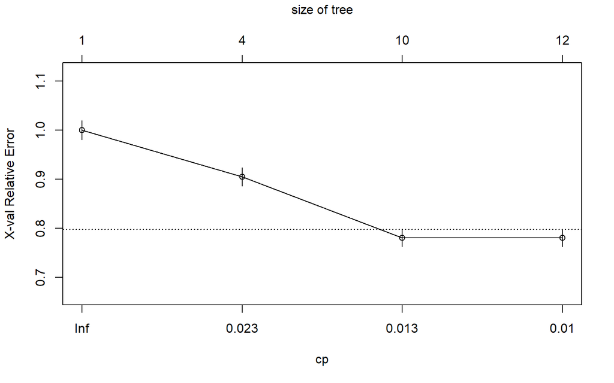

```r
plotcp(dtree_default)
```

```r
# Full tree
dtree_full <- rpart::rpart(eyes_state ~ ., method = "class",
                           data =training,
                           control = rpart.control(minsplit = 1, cp = 0))

#rpart.plot(dtree_full, type = 2, extra = 101, fallen.leaves = F,
#           main = "Complete Decision Tree for eye_state")
which.min(dtree_full$cptable[, "xerror"]) # 27
```

```
## 30
## 30
```

```r
printcp(dtree_full)
```

```
##
## Classification tree:
## rpart::rpart(formula = eyes_state ~ ., data = training, method = "class",
##     control = rpart.control(minsplit = 1, cp = 0))
##
## Variables actually used in tree construction:
##  [1] EEG1  EEG10 EEG11 EEG12 EEG13 EEG14 EEG15 EEG16 EEG2  EEG3  EEG4  EEG5
## [13] EEG7  EEG8  EEG9
##
## Root node error: 2000/8193 = 0.24411
##
## n= 8193
##
##            CP nsplit rel error xerror     xstd
## 1  0.03433333      0    1.0000 1.0000 0.019441
```

[output cut: 41 more lines]

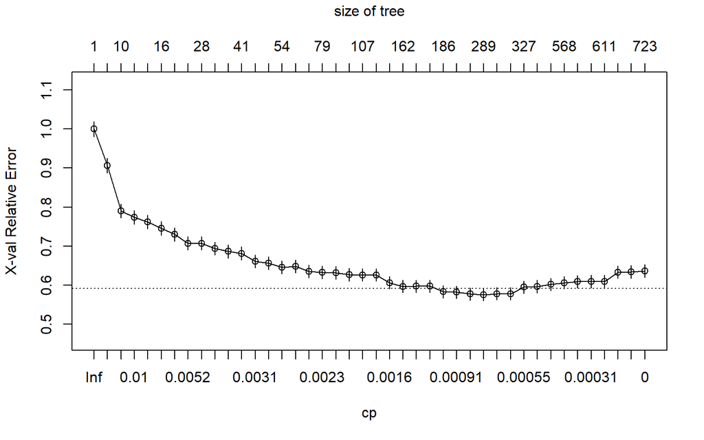

```r
plotcp(dtree_full)
```

```r
# Optimal tree
prune_optimal <- dtree_full$cptable[which.min(dtree_full$cptable[, "xerror"]), "CP"]
dtree_optimal <- prune(dtree_full, cp = prune_optimal)

#rpart.plot(dtree_optimal, type = 2, extra = 101, fallen.leaves = F,
#           main = "Pruned Classification Tree for Seeds")
printcp(dtree_optimal)
```

```
##
## Classification tree:
## rpart::rpart(formula = eyes_state ~ ., data = training, method = "class",
##     control = rpart.control(minsplit = 1, cp = 0))
##
## Variables actually used in tree construction:
##  [1] EEG1  EEG10 EEG11 EEG12 EEG13 EEG14 EEG15 EEG16 EEG2  EEG3  EEG4  EEG5
## [13] EEG7  EEG8  EEG9
##
## Root node error: 2000/8193 = 0.24411
##
## n= 8193
##
##            CP nsplit rel error xerror     xstd
## 1  0.03433333      0    1.0000 1.0000 0.019441
```

[output cut: 29 more lines]

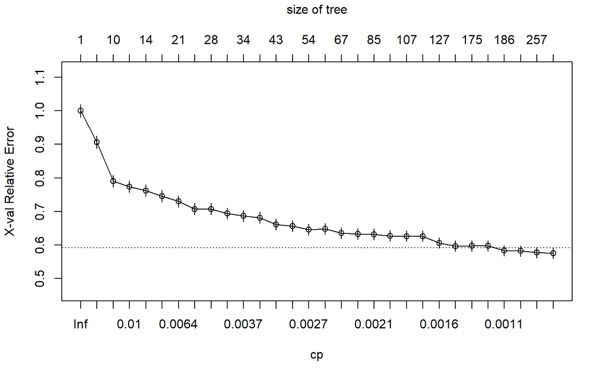

```r
plotcp(dtree_optimal)
```

**Hyperparameter tuning** was carried out the same way as in Assignment 1, with default decision tree first, then the full decision tree and from that, the final pruned tree.

This model’s performance is not so good, even with hyperparameter tuning, but we’ll see how it compares to the rest later.

```r
training[, .N, eyes_state] # closed eye_state is undersampled
```

```
##    eyes_state     N
##        <fctr> <int>
## 1:     closed  2000
## 2:       open  6193
```

We can see the closed eye state is somewhat undersampled, so we need to keep an eye on models that might focus too heavily on “open” outcomes.

```r
# Confusion Matrix and relevant metrics
training_x <- training[, !"eyes_state"]
training_y <- training[, eyes_state]
testing_x <- testing[, !"eyes_state"]
testing_y <- testing[, eyes_state]

predict_y_dtree_optimal <- predict(dtree_optimal, newdata = testing_x, type = "class")

table(predict_y_dtree_optimal, testing_y) # raw confusion matrices
```

```
##                        testing_y
## predict_y_dtree_optimal closed open
##                  closed   1060  161
##                  open      620 1903
```

```r
dctree_cm<- confusionMatrix(predict_y_dtree_optimal, reference=testing_y, mode="prec_recall")
confusionMatrix(predict_y_dtree_optimal, reference=testing_y, mode="prec_recall")
```

```
## Confusion Matrix and Statistics
##
##           Reference
## Prediction closed open
##     closed   1060  161
##     open      620 1903
##
##                Accuracy : 0.7914
##                  95% CI : (0.778, 0.8043)
##     No Information Rate : 0.5513
##     P-Value [Acc > NIR] : < 2.2e-16
##
##                   Kappa : 0.5674
##
##  Mcnemar's Test P-Value : < 2.2e-16
##
##               Precision : 0.8681
##                  Recall : 0.6310
##                      F1 : 0.7308
##              Prevalence : 0.4487
##          Detection Rate : 0.2831
##    Detection Prevalence : 0.3261
##       Balanced Accuracy : 0.7765
##
##        'Positive' Class : closed
##
```

We can see that the model’s performance is okay, it has good accuracy and precision, but recall is bad

### Part 2: Support Vector Machines

```r
# SVM -----------------------------------------------------------------------
#library(e1071)
# We evaluate each kernel
evaluate_kernel_fun <- function(type) {
  svm_model <- svm(eyes_state ~ .,
               data = training,
               kernel = type,
               type = "C-classification")

  pred <- predict(svm_model, testing)
  cmatrix <- confusionMatrix(pred, testing$eyes_state)
  return(cmatrix$overall['Accuracy'])
}

kernels <- c("linear", "polynomial", "radial", "sigmoid")
results <- sapply(kernels, evaluate_kernel_fun)

data.frame(Kernel = kernels, Accuracy = results)
```

```
##                         Kernel  Accuracy
## linear.Accuracy         linear 0.5512821
## polynomial.Accuracy polynomial 0.5779915
## radial.Accuracy         radial 0.6172543
## sigmoid.Accuracy       sigmoid 0.5197650
```

As we can see, the highest accuracy model is the RBF, so we’ll go with that one.

```r
# Training with a smaller size
small_train <- training[sample(nrow(training), 2000), ]

# class balance
small_train[, .N, eyes_state]
```

```
##    eyes_state     N
##        <fctr> <int>
## 1:       open  1500
## 2:     closed   500
```

```r
# radial kernel performed best, tune with that kernel
tuning_rbf <- tune.svm(eyes_state ~ .,
                   data = small_train,
                   kernel = "radial",
                   cost = c(0.01, 0.1, 1, 10, 100),
                   gamma = 5*10^(-2:2))

# create model with the correct kernel and parameters
best_svm_model <- svm(eyes_state ~ .,
                     data = small_train,
                     type = "C-classification",
                     kernel = "radial",  # Using radial since it performed best
                     cost = tuning_rbf$best.parameters$cost,
                     gamma = tuning_rbf$best.parameters$gamma,
                     scale = TRUE)

pred_test <- predict(best_svm_model, testing)
accuracy <- mean(pred_test == testing$eyes_state)
accuracy
```

```
## [1] 0.8581731
```

```r
svm_cm <- confusionMatrix(data = factor(pred_test),
                      reference = factor(testing$eyes_state),
                      mode = "prec_recall")
confusionMatrix(data = factor(pred_test),
                      reference = factor(testing$eyes_state),
                      mode = "prec_recall")
```

```
## Confusion Matrix and Statistics
##
##           Reference
## Prediction closed open
##     closed   1232   83
##     open      448 1981
##
##                Accuracy : 0.8582
##                  95% CI : (0.8466, 0.8692)
##     No Information Rate : 0.5513
##     P-Value [Acc > NIR] : < 2.2e-16
##
##                   Kappa : 0.7074
##
##  Mcnemar's Test P-Value : < 2.2e-16
##
##               Precision : 0.9369
##                  Recall : 0.7333
##                      F1 : 0.8227
##              Prevalence : 0.4487
##          Detection Rate : 0.3291
##    Detection Prevalence : 0.3512
##       Balanced Accuracy : 0.8466
##
##        'Positive' Class : closed
##
```

By using a sample size of 2000 and RBF as my kernel, I managed to develop a better model, with high F1 score and Precision, but Recall is pretty bad In comparison to the decision tree, this is still an improvement improvement.

### Part 3: KNN

```r
# KNN ----------------------------------------------------------------
k <- seq(1, 55, 2)
knn <- lapply(k, \(x) knn.cv(train = training_x, cl = training_y, k = x))

accuracies <- sapply(knn, \(x) confusionMatrix(data = x, reference = training_y)$overall["Accuracy"])
plot_ly(x = k, y = accuracies, type = "scatter", mode = "line")
```

[interactive chart not shown]

```r
knn_cm <- confusionMatrix(data = knn[[((5-1)/2)]], reference = training_y, mode="prec_recall")
#Note for self: knn[[2]] accesses the second element in list of KNN models
```

### Part 4: Random Forest, AdaBoost, and XGBoost.

**Random Forest**

```r
# RF --------------------------------------------------------------------
rf.orig <- ranger(x = training_x, y = training_y)
rf.orig
```

```
## Ranger result
##
## Call:
##  ranger(x = training_x, y = training_y)
##
## Type:                             Classification
## Number of trees:                  500
## Sample size:                      8193
## Number of independent variables:  15
## Mtry:                             3
## Target node size:                 1
## Variable importance mode:         none
## Splitrule:                        gini
## OOB prediction error:             8.63 %
```

```r
#confusionMatrix(data=rf.orig$predictions, reference = training_y,
#                mode="prec_recall")

my_pred <- predict(object = rf.orig, data = testing_x)
rf_cm <- confusionMatrix(data = my_pred$predictions, reference = testing_y, mode = "prec_recall")
confusionMatrix(data = my_pred$predictions, reference = testing_y, mode = "prec_recall")
```

```
## Confusion Matrix and Statistics
##
##           Reference
## Prediction closed open
##     closed   1107   17
##     open      573 2047
##
##                Accuracy : 0.8424
##                  95% CI : (0.8303, 0.8539)
##     No Information Rate : 0.5513
##     P-Value [Acc > NIR] : < 2.2e-16
##
##                   Kappa : 0.6714
##
##  Mcnemar's Test P-Value : < 2.2e-16
##
##               Precision : 0.9849
##                  Recall : 0.6589
##                      F1 : 0.7896
##              Prevalence : 0.4487
##          Detection Rate : 0.2957
##    Detection Prevalence : 0.3002
##       Balanced Accuracy : 0.8253
##
##        'Positive' Class : closed
##
```

As we can see, we have **pretty good prediction precision**, but our **recall is not exactly good**, this means that the model probably realised that we have more “open” data and it defaults to predicting that state to achieve high results.

We need to rebalance for Random Forest

```r
training.rose <- ovun.sample(eyes_state ~ ., data = training,
                              method = "over", seed = 123, p = 0.4)$data
setDT(training.rose)
training[, .N, eyes_state]
```

```
##    eyes_state     N
##        <fctr> <int>
## 1:     closed  2000
## 2:       open  6193
```

```r
training.rose[, .N, eyes_state]
```

```
##    eyes_state     N
##        <fctr> <int>
## 1:       open  6193
## 2:     closed  4084
```

```r
training.rose_x <- training.rose[,!"eyes_state"]
training.rose_y <- training.rose[, eyes_state]

rf.rebalanced <- ranger(x = training.rose_x, y= training.rose_y) # with default parameters

confusionMatrix(data = rf.rebalanced$predictions, reference = training.rose_y,
                mode = "prec_recall")
```

```
## Confusion Matrix and Statistics
##
##           Reference
## Prediction open closed
##     open   6132    145
##     closed   61   3939
##
##                Accuracy : 0.98
##                  95% CI : (0.9771, 0.9826)
##     No Information Rate : 0.6026
##     P-Value [Acc > NIR] : < 2.2e-16
##
##                   Kappa : 0.958
##
##  Mcnemar's Test P-Value : 7.343e-09
##
##               Precision : 0.9769
##                  Recall : 0.9902
##                      F1 : 0.9835
##              Prevalence : 0.6026
##          Detection Rate : 0.5967
##    Detection Prevalence : 0.6108
##       Balanced Accuracy : 0.9773
##
##        'Positive' Class : open
##
```

```r
my_pred_reb <- predict(rf.rebalanced, data = testing_x)
rf.re_cm <- confusionMatrix(data = my_pred_reb$predictions, reference = testing_y,
                mode = "prec_recall")
confusionMatrix(data = my_pred_reb$predictions, reference = testing_y,
                mode = "prec_recall")
```

```
## Confusion Matrix and Statistics
##
##           Reference
## Prediction closed open
##     closed   1178   26
##     open      502 2038
##
##                Accuracy : 0.859
##                  95% CI : (0.8474, 0.87)
##     No Information Rate : 0.5513
##     P-Value [Acc > NIR] : < 2.2e-16
##
##                   Kappa : 0.7072
##
##  Mcnemar's Test P-Value : < 2.2e-16
##
##               Precision : 0.9784
##                  Recall : 0.7012
##                      F1 : 0.8169
##              Prevalence : 0.4487
##          Detection Rate : 0.3146
##    Detection Prevalence : 0.3216
##       Balanced Accuracy : 0.8443
##
##        'Positive' Class : closed
##
```

We managed to marginally improve Recall by resampling.

**Feature importance test**

```r
# Feature importance
training.rose[, random:=runif(nrow(training.rose), 1, 100)]
fit.ranger <- ranger(eyes_state ~ ., data = training.rose, importance = "permutation")
imp <- importance(fit.ranger)
imp <- data.table(Feature = names(imp), importance = imp)
plot_ly(data=imp, x=~Feature, y=~importance, type="bar") %>%
  layout(xaxis = list(categoryorder="total descending"))
```

[interactive chart not shown]

```r
# Confirmed. We can remove the random feature
training.rose[, random :=NULL]
```

We can see that EEG3, EEG5 and EEG16 are the top 3 most important features regarding model performance. Introducing a random sample makes it get to the end of the importances, which is good.

**AdaBoost**

```r
ada <- adabag::boosting(eyes_state ~ ., data = training.rose, mfinal = 200)
my_pred_adaboost <- predict(ada, newdata = testing_x)
ada_cm <- confusionMatrix(as.factor(my_pred_adaboost$class), testing_y, mode = "prec_recall")
confusionMatrix(as.factor(my_pred_adaboost$class), testing_y, mode = "prec_recall")
```

```
## Confusion Matrix and Statistics
##
##           Reference
## Prediction closed open
##     closed   1249  114
##     open      431 1950
##
##                Accuracy : 0.8544
##                  95% CI : (0.8427, 0.8656)
##     No Information Rate : 0.5513
##     P-Value [Acc > NIR] : < 2.2e-16
##
##                   Kappa : 0.7005
##
##  Mcnemar's Test P-Value : < 2.2e-16
##
##               Precision : 0.9164
##                  Recall : 0.7435
##                      F1 : 0.8209
##              Prevalence : 0.4487
##          Detection Rate : 0.3336
##    Detection Prevalence : 0.3640
##       Balanced Accuracy : 0.8441
##
##        'Positive' Class : closed
##
```

From the confusion matrix of AdaBoost, it’s obvious that this is a better fitting model, since **Accuracy and Precision** are high, but **Recall** isn’t low either.

**XGBoost**

```r
# We already have all columns in numerical type, which XGBoost requires
# make sure to use matrix and have 0, 1 in categorical
training.rose_y_xgb <- as.numeric(training.rose_y == "closed")

# Train XGBoost model
xgb_model <- xgboost(data = as.matrix(training.rose_x),
                    label = training.rose_y_xgb,
                    nrounds = 300,        # Start with fewer rounds to avoid overfitting
                    objective = "binary:logistic",
                    eval_metric = "error",
                    verbose = 0)

test_matrix <- as.matrix(testing_x)
xgb_pred_prob <- predict(xgb_model, test_matrix)
xgb_pred_class <- ifelse(xgb_pred_prob > 0.5, "closed", "open") # we assign label, because XGBoost is a regression algorithm

# Convert to factor with the same levels as testing_y for confusionMatrix
xgb_pred_factor <- factor(xgb_pred_class, levels = levels(testing_y))

# Evaluate model performance
xgb_cm <- confusionMatrix(data = xgb_pred_factor,
                                  reference = testing_y,
                                  mode = "prec_recall")
confusionMatrix(data = xgb_pred_factor,
                                  reference = testing_y,
                                  mode = "prec_recall")
```

```
## Confusion Matrix and Statistics
##
##           Reference
## Prediction closed open
##     closed   1331   40
##     open      349 2024
##
##                Accuracy : 0.8961
##                  95% CI : (0.8859, 0.9057)
##     No Information Rate : 0.5513
##     P-Value [Acc > NIR] : < 2.2e-16
##
##                   Kappa : 0.7863
##
##  Mcnemar's Test P-Value : < 2.2e-16
##
##               Precision : 0.9708
##                  Recall : 0.7923
##                      F1 : 0.8725
##              Prevalence : 0.4487
##          Detection Rate : 0.3555
##    Detection Prevalence : 0.3662
##       Balanced Accuracy : 0.8864
##
##        'Positive' Class : closed
##
```

By interpreting the confusion matrix of XGBoost, we see that **Accuracy and Precision** are high, but **Recall is lacking** again.

## 4. Display a table summarizing the performance of all models on the training and on the test set (Accuracy, Precision, Recall, and F1-Score)

```r
# The confusion matrices in question:
# dctree_cm,
# - svm_cm,
# - knn_cm,
# - rf_cm,
# - rf.re_cm,
# - ada_cm,
# - xgb_cm

# A function that extracts metrics from the confusion Matrices
get_metrics <- function(matrix) {
  accuracy <- matrix$overall['Accuracy']
  precision <- matrix$byClass['Precision']
  recall <- matrix$byClass['Recall']
  f1 <- matrix$byClass['F1']
  return(c(accuracy,
           precision,
           recall,
           f1))}

# Extracting the appropriate metric using the function
metrics <- list(
  DecisionTree = get_metrics(dctree_cm),
  SVM          = get_metrics(svm_cm),
  KNN          = get_metrics(knn_cm),
  RF = get_metrics(rf_cm),
  RF_Re        = get_metrics(rf.re_cm),
  AdaBoost     = get_metrics(ada_cm),
  XGBoost      = get_metrics(xgb_cm)
)

performance_table <- as.data.frame(do.call(rbind, metrics)) # we can use do.call for a list of arguments here
performance_table
```

```
##               Accuracy Precision    Recall        F1
## DecisionTree 0.7913996 0.8681409 0.6309524 0.7307825
## SVM          0.8581731 0.9368821 0.7333333 0.8227045
## KNN          0.9410472 0.9397101 0.8105000 0.8703356
## RF           0.8424145 0.9848754 0.6589286 0.7895863
## RF_Re        0.8589744 0.9784053 0.7011905 0.8169209
## AdaBoost     0.8544338 0.9163610 0.7434524 0.8209004
## XGBoost      0.8961004 0.9708242 0.7922619 0.8725008
```